# Lecture 8: The Linear Model

Analysing Data, Spring 2020

Dr Jennifer Mankin

Click for slides

## Overview

- Week 5: Measures of Association
- Week 6: Comparing Two Means
- Week 7: Lab Report Writing
- TODAY: The Linear Model

### Today’s Topics

- What is (statistical) modelling?
- The Linear Model
  - Categorical predictor: the Red study
  - Continuous predictor: the GenSex data
- Using the Linear Model
  - Equation and elements
  - Evaluating Significance
  - Evaluating Model Fit

## Statistical Models

- We are now entering the world of statistical modelling!
- A **statistical model** is a mathematical expression that captures the relationship between variables
  - All of our test statistics (*r*, *t*, etc.) are actually models
- Why create statistical models?

### Models

- A model is a simplified version of something in the world
  - We want to **predict** what will happen in the world
  - But the world is complex and full of noise (randomness)
- We can build a model to try to capture the important elements
  - We can change/adjust the model to see what might happen

### Aeroplanes

- You could make a real aeroplane - but this is very difficult!
  - Dangerous and difficult-to-use materials
  - Big, heavy, complicated, and expensive
- Before you attempt that, you could make a model instead
- Has the same important elements: wings, fuselage, propeller, etc
  - You can use materials that are more easily accessible
  - Helps you **predict** how a real aeroplane will work

### Statistical Models

- Statistical models are *mathematical* representations
  - Contain the most important elements (in theory!)
    - e.g. the variables that have the strongest relationships
  - Made using more easily accessible materials
    - e.g. samples of data rather than populations
    - e.g. operationalised variables
- We use statistical models to **make predictions** about the world
  - This is always subject to some degree of **error**

### Predictors and Outcomes

- Now we start assigning our variables roles to play
- The **outcome** is the variable we want to explain
- The **predictors** are variables that may have a relationship with the outcome
  - We measure or manipulate the predictors, then look for a systematic change in the outcome
  - NB: **YOU** (the researcher) assign these roles!

### General Model Equation

Outcome = model + error

- We can use models to **predict** the outcome for a particular case
- This is always subject to some degree of **error**

## Seeing Red

- Last week’s example: the Red Study *t*-test
  - We created a linear model capturing the relationship of interest
    - Predictor: frame colour (white or red)
    - Outcome: Composite attractiveness rating
  - How does the linear model capture this relationship?

### Red revisited

Compare differences in means using a straight line

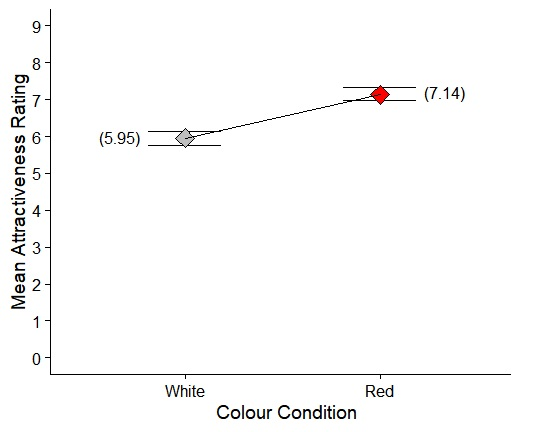

### Drawing Lines

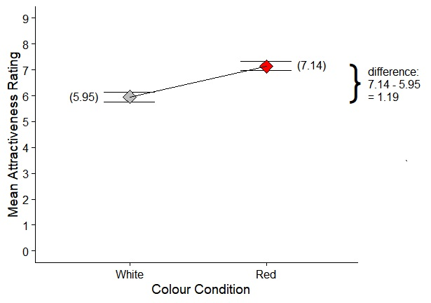

- The line starts from the mean of the `white` (control) group
  - This is the **intercept**, which we will call *b*<sub>0</sub>
  - The value of the outcome when the predictor is 0
- When we change the frame colour from `white` to `red`, the predicted mean attractiveness rating changes by 1.19
  - This is the **slope** of the line, which we will call *b*<sub>1</sub>
  - The change in the outcome for every **unit change** in the predictor

### The Linear Model

- We now have two parameters, *b*<sub>0</sub> and *b*<sub>1</sub>, that describe a line
  - This line is our **model**
- General model equation: outcome = model + error
- General linear model: outcome = *b*<sub>0</sub> + *b*<sub>1</sub>(predictor<sub>1</sub>) + error
  - May be familiar as e.g. y = mx + b

### Seeing Red Lines

outcome = *b*<sub>0</sub> + *b*<sub>1</sub>(predictor<sub>1</sub>) + error

- Outcome: attractiveness
- Predictor: frame colour
- *b*<sub>0</sub>: mean of the baseline (white) group (the intercept)
- *b*<sub>1</sub>: change in means between white and red groups (the slope)
- LM for Red study: attractiveness = 5.95 + 1.19(group) + error

### Red Lines in R

```r
elliot_lm <- lm(attract ~ group, data = elliot)
elliot_lm %>% summary()

Call:
lm(formula = attract ~ group, data = elliot)

Residuals:
     Min       1Q   Median       3Q      Max
-2.28169 -0.57941  0.05164  0.52743  1.86076

Coefficients:
                  Estimate Std. Error t value
(Intercept)        5.94836    0.09506  62.578
groupexperimental  1.19088    0.13098   9.092
                  Pr(>|t|)
(Intercept)        < 2e-16 ***
groupexperimental 5.92e-16 ***
---
Signif. codes:
0 '***' 0.001 '**' 0.01 '*' 0.05 '.' 0.1 ' ' 1

Residual standard error: 0.801 on 148 degrees of freedom
Multiple R-squared:  0.3584,    Adjusted R-squared:  0.354
F-statistic: 82.66 on 1 and 148 DF,  p-value: 5.924e-16
```

## Welcome to `lm()`!

- Today’s new function is a very important one
  - We will use it for the rest of the term and…
  - It will be very important next year as well!
- What does it do?
  - Creates a **l**inear **m**odel -> `lm()`
  - A statistical model that looks like a line

### Basic Anatomy of `lm()`

`lm(outcome ~ predictor, data = data)`

- Create a linear model between an outcome variable and a predictor variable in the dataset `data`
- Three primary ideas for today:
  - Calculate and interpret the model equation
  - Evaluate significance
  - Evaluate model fit
- Let’s have another look at the GenSex data

## Creating the Model

- We could draw a line to capture the trend in this data…

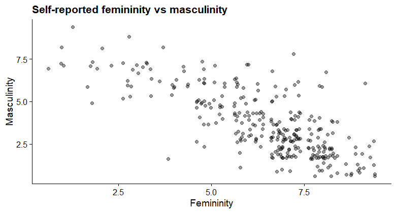

[figure not shown]

### Modelling Gender

- Week 5: **correlation** between femininity and masculinity
  - Remember: *r* expresses degree and direction of the relationship
- Today: create a linear model using the same variables
  - We could then use this model to make **predictions**
- How would you write the command in R to create this model?

```r
gender_lm <- lm(Gender_masc_1 ~ Gender_fem_1, data = gensex)
gender_lm %>% summary()

Call:
lm(formula = Gender_masc_1 ~ Gender_fem_1, data = gensex)

Residuals:
    Min      1Q  Median      3Q     Max
-3.6341 -0.6461 -0.2413  0.5683  4.7587

Coefficients:
             Estimate Std. Error t value Pr(>|t|)
(Intercept)   8.82456    0.26358   33.48   <2e-16
Gender_fem_1 -0.79761    0.03969  -20.10   <2e-16

(Intercept)  ***
Gender_fem_1 ***
---
Signif. codes:
0 '***' 0.001 '**' 0.01 '*' 0.05 '.' 0.1 ' ' 1

Residual standard error: 1.219 on 304 degrees of freedom
Multiple R-squared:  0.5706,    Adjusted R-squared:  0.5692
F-statistic: 403.9 on 1 and 304 DF,  p-value: < 2.2e-16
```

outcome = *b*<sub>0</sub> + *b*<sub>1</sub>(predictor<sub>1</sub>) + error

- Outcome: Masculinity
- Predictor: Femininity
- *b*<sub>0</sub>: value of masculinity when femininity is 0 (the intercept)
- *b*<sub>1</sub>: change in masculinity associated with a unit change in femininity (the slope)
- Linear model: masculinity = 8.82 + -0.8(femininity) + error

### Predicting Gender

- We can now use this model to **predict** someone’s rating of masculinity, if we know their rating of femininity
  - e.g., someone who is not very feminine (rating: 3)
- masculinity = 8.82 + -0.8(femininity) + error
  - masculinity = 8.82 + -0.8(3) + error
  - masculinity = 6.43+ error
- So, we predict that someone with a femininity of 3 will have a masculinity rating of 6.43
  - This is subject to some (UNKNOWABLE) degree of error

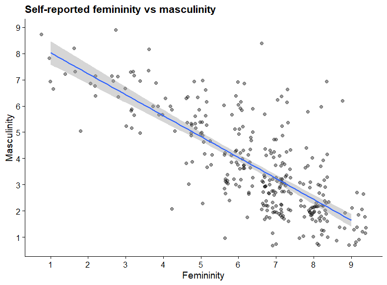

### Interim Summary

- We have a **linear model** that captures the relationship between x (the predictor, femininity) and y (the outcome, masculinity)
  - The model is described by an intercept (*b*<sub>0</sub>) and a slope (*b*<sub>1</sub>)
  - We can use this model to **predict** the outcome for new cases
- But…is this model actually useful?
  - Does it capture a significant relationship?
  - Is this model any good?

## Evaluating Significance

masculinity = 8.82 + -0.8(femininity) + error

- Most important element: *b*<sub>1</sub>
  - Captures the relationship between the predictor and the outcome
  - Our **test statistic**!
- Captures the degree and direction of the relationship
  - *b*<sub>1</sub> = -0.8
  - Negative value: as femininity increases, masculinity decreases
- Is this relationship significant?

### Recipe for Statistical Testing

- As always, we will need:
  - Data
  - A test statistic
  - The distribution of that test statistic
  - The probability *p* of finding a test statistic as large as the one we have (or larger) if the null hypothesis is true

### Null Hypothesis of *b*<sub>1</sub>

- *b*<sub>1</sub> captures the relationship between variables
  - If *b*<sub>1</sub> is 0, there is **no relationship** between the variables
  - So, *b*<sub>1</sub> = 0 represents the null hypothesis

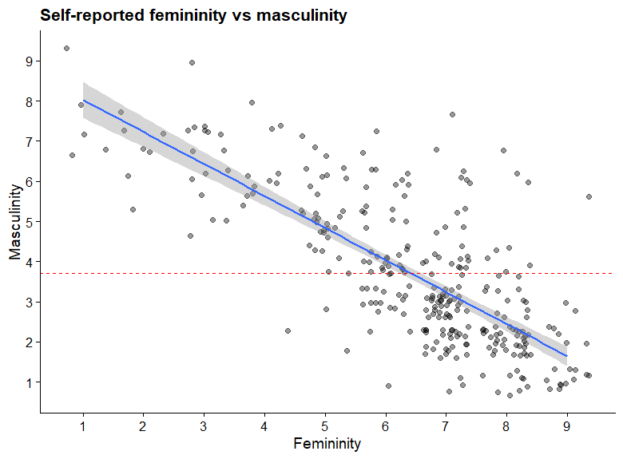

- Is our value of *b*<sub>1</sub> different from 0?
  - Yes: it is -0.8
- Is it different **enough** from 0 to believe that it is unlikely to be 0 in the population?
  - To find out, compare estimate of *b*<sub>1</sub> to the distribution of *b*<sub>1</sub>
  - Is this starting to sound familiar?

### Can You Hear Me Now?

- Remember our signal-to-noise ratio
  - Signal: the estimate of *b*<sub>1</sub>
  - Noise: the error, here the standard error of *b*<sub>1</sub>
- The bigger the signal is compared to the noise, the less likely it is to actually just be noise itself!
- Mathematically, we can represent this by signal/noise
- So, we divide *b*<sub>1</sub> by the standard error of *b*<sub>1</sub>, which gives us…

### Deja Vu All Over Again

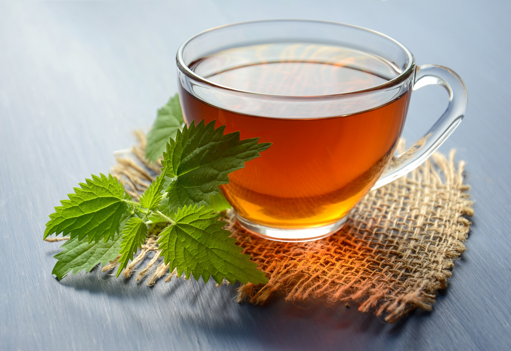

- If this sounds familiar: we’ve seen this before!
  - As explained in [Tutorial 4](https://mivalek.github.io/adata/tut/tut_05_stats_fundamentals.html), it is **exactly** this scenario that produces the *t*-distribution
- So, we will (again!) use *t* to get the significance of *b*<sub>1</sub>

### Linear Model Output, Revisited

Femininity significantly predicted masculinity (*b* = -0.8, SE(*b*) = 0.04, *t* = -20.10, *p* < .001)

```
Call:
lm(formula = Gender_masc_1 ~ Gender_fem_1, data = gensex)

Residuals:
    Min      1Q  Median      3Q     Max
-3.6341 -0.6461 -0.2413  0.5683  4.7587

Coefficients:
             Estimate Std. Error t value Pr(>|t|)
(Intercept)   8.82456    0.26358   33.48   <2e-16
Gender_fem_1 -0.79761    0.03969  -20.10   <2e-16

(Intercept)  ***
Gender_fem_1 ***
---
Signif. codes:
0 '***' 0.001 '**' 0.01 '*' 0.05 '.' 0.1 ' ' 1

Residual standard error: 1.219 on 304 degrees of freedom
Multiple R-squared:  0.5706,    Adjusted R-squared:  0.5692
F-statistic: 403.9 on 1 and 304 DF,  p-value: < 2.2e-16
```

### Interim Summary, Again

- We have a **linear model** that captures the relationship between *x* (the predictor, femininity) and *y* (the outcome, masculinity)
  - The model is described by an intercept (*b*<sub>0</sub>) and a slope (*b*<sub>1</sub>)
  - We can use this model to **predict** the outcome for new cases
  - This model also captures a statistically significant relationship
- Is this model any good?

## Quantifying Model Fit

- The **correlation** between masculinity and femininity was -0.76
  - That correlation squared is 0.57
  - Take another look at the `lm() %>% summary()` output…

### The Model

```r
gender_lm %>% summary()

Call:
lm(formula = Gender_masc_1 ~ Gender_fem_1, data = gensex)

Residuals:
    Min      1Q  Median      3Q     Max
-3.6341 -0.6461 -0.2413  0.5683  4.7587

Coefficients:
             Estimate Std. Error t value Pr(>|t|)
(Intercept)   8.82456    0.26358   33.48   <2e-16
Gender_fem_1 -0.79761    0.03969  -20.10   <2e-16

(Intercept)  ***
Gender_fem_1 ***
---
Signif. codes:
0 '***' 0.001 '**' 0.01 '*' 0.05 '.' 0.1 ' ' 1

Residual standard error: 1.219 on 304 degrees of freedom
Multiple R-squared:  0.5706,    Adjusted R-squared:  0.5692
F-statistic: 403.9 on 1 and 304 DF,  p-value: < 2.2e-16
```

### R<sup>2</sup> in LM

- The squared correlation coefficient
- Helps us **quantify** how good the model is
  - How can we interpret this?

### Significance vs Model Fit

- Significance and model fit are not the same thing
  - Significance: how likely we are to find a *b*-value as large as the one we have observed, or larger, if the null hypothesis is true
  - Model fit: how good the model actually is
    - How well it fits (explains) the data we have
    - How well it is likely to **generalise** to the population

### A Step Back

- We’re deep down the statistical rabbit hole now!
  - What are we trying to accomplish?
  - Investigate scientifically how people experience gender
- A good model is valid and reliable for **everyone**, not just our sample

### Accounting for Variance

- In our study, people gave different responses to our questions
  - Some people gave high femininity ratings, others low ratings
  - In other words: their responses **varied**
- We have stored the responses each person gave as **variables**
  - i.e. things that can vary!

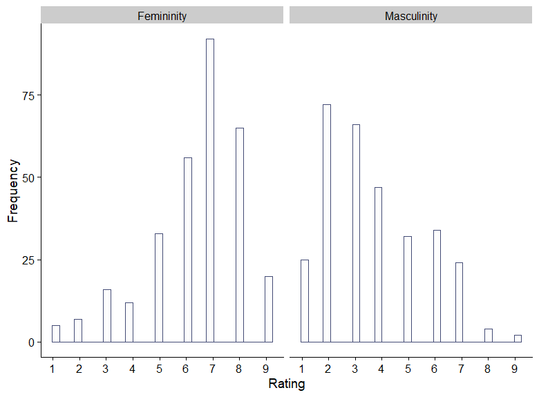

- We want to explain this variance, particularly in the outcome
  - **Why** do people percieve themselves as more or less masculine?
- A good model will **explain more variance** in the outcome
  - It will capture why people respond the way that they do
- A poor model will **not** explain very much variance

### Back to Model Fit

- So, we need a way to quantify variance explained
- Good news! This is R<sup>2</sup>
  - Expresses how much of the variance in the outcome is explained by the predictor(s)
  - Multiply by 100 to get percent variance explained

#### The Model Again

```r
gender_lm %>% summary()

Call:
lm(formula = Gender_masc_1 ~ Gender_fem_1, data = gensex)

Residuals:
    Min      1Q  Median      3Q     Max
-3.6341 -0.6461 -0.2413  0.5683  4.7587

Coefficients:
             Estimate Std. Error t value Pr(>|t|)
(Intercept)   8.82456    0.26358   33.48   <2e-16
Gender_fem_1 -0.79761    0.03969  -20.10   <2e-16

(Intercept)  ***
Gender_fem_1 ***
---
Signif. codes:
0 '***' 0.001 '**' 0.01 '*' 0.05 '.' 0.1 ' ' 1

Residual standard error: 1.219 on 304 degrees of freedom
Multiple R-squared:  0.5706,    Adjusted R-squared:  0.5692
F-statistic: 403.9 on 1 and 304 DF,  p-value: < 2.2e-16
```

### Interpreting Model Fit

- The value for R<sup>2</sup> was 0.5706
  - This means that 57.06% of the variance in ratings of masculinity was explained by ratings of femininity
  - The remaining variance is due to influences not measured and/or included in our model
- The adjusted R<sup>2</sup> was 0.5692
  - This means that if we applied this same model to the population, we would expect to be able to explain 56.92% of the variance in ratings of masculinity
- We want R<sup>2</sup> and adjusted R<sup>2</sup> to be big, and similar to each other

### Interim Summary, Once More

- We have a **linear model** that captures the relationship between *x* (the predictor, femininity) and *y* (the outcome, masculinity)
  - The model is described by an intercept (*b*<sub>0</sub>) and a slope (*b*<sub>1</sub>)
  - We can use this model to **predict** the outcome for new cases
  - The model captures a statistically significant relationship and explains 57% of the variance in the outcome

## Final Notes

- Correlation (*r*) vs LM (*b*<sub>1</sub>)
- Applying to the Red model

### Correlation (*r*) vs LM (*b*<sub>1</sub>)

- Both show degree and direction of a relationship between variables
  - Positive value = positive relationship
  - Negative value = negative relationship
  - Larger number = stronger relationship

**Not** the same thing!

| Correlation | LM (Regression) |
| --- | --- |
| X and Y interchangeable | X predicts Y |
| Single number | Equation |
| Used to quantify | Used to predict |

### Seeing Red, Once More

How can you interpret this model?

```
Call:
lm(formula = attract ~ group, data = elliot)

Residuals:
     Min       1Q   Median       3Q      Max
-2.28169 -0.57941  0.05164  0.52743  1.86076

Coefficients:
                  Estimate Std. Error t value
(Intercept)        5.94836    0.09506  62.578
groupexperimental  1.19088    0.13098   9.092
                  Pr(>|t|)
(Intercept)        < 2e-16 ***
groupexperimental 5.92e-16 ***
---
Signif. codes:
0 '***' 0.001 '**' 0.01 '*' 0.05 '.' 0.1 ' ' 1

Residual standard error: 0.801 on 148 degrees of freedom
Multiple R-squared:  0.3584,    Adjusted R-squared:  0.354
F-statistic: 82.66 on 1 and 148 DF,  p-value: 5.924e-16
```

## Summary

- The linear model (LM) captures the relationship between at least one predictor, *x*, and an outcome, *y*
  - Linear model equation: outcome = *b*<sub>0</sub> + *b*<sub>1</sub>(predictor) + error
  - Most important result is the parameter *b*<sub>1</sub>, which expresses the change in *y* for each unit change in *x*
  - Significance of *b*<sub>1</sub> evaluated with *t*
  - Model fit evaluated with R<sup>2</sup> and adjusted R<sup>2</sup>

## Questions?

**Don’t forget to save this page on your computer, otherwise you will lose all notes!**